# Simulations Documentation

The APSIM AgPasture Model

Validation

Sensibility

AGPRyegrass Interface

AGPWhiteClover Interface

Science Documentation

Species Table

References

[figure not shown]

# 1 The APSIM AgPasture Model

AgPasture is a model developed to simulate pasture growth in the APSIM framework. It was initially based on the plant physiological model of Thornley et al., 1990, as were the models SGS/DairyMod/EcoMod, presented by Johnson et al., 2008. Today in AgPasture, the plant processes were adapted from EcoMod but all environmental factors and partition of resources is done by other models in the APSIM framework.The main purpose of AgPasture is to simulate mixed pastures but based on individual calculations for each species of photosynthesis, respiration, dry matter accumulation and partitioning and tissue turnover as presented by Li et al., 2011. It simulates pastures composed by C3 and C4 grasses, legumes and forbs. Now AgPasture has the sward component that is responsible for integrating the outputs obtained for each species and controlling management aspects, such as grazing. The base species in AgPasture is a generic temperate C3 grass parameterised as a generic ryegrass. All simulations are based on an stablished pasture, so there is no development from seeds. The proportion of species in the sward varies according to environmental effects, water and nutrient extraction ability and effects of harvests (cutting or grazing) on each of the species in the sward. Each species is described as a set of organs (Figure 1) and these organs are described by tissue pools (Figure 2).

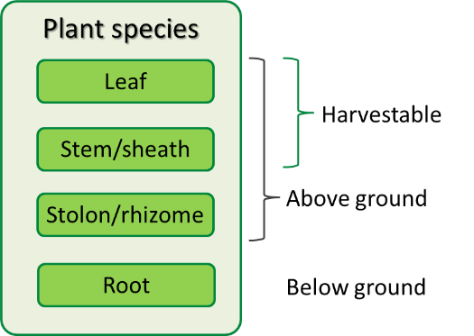

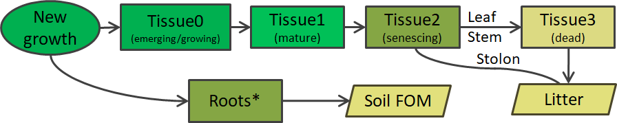

The water demand is calculated by the MicroClimate model (originally micromet; Snow et al., 2004). Water availability is then calculated according to the root distribution and the KL parameter in the soil. The communication wih the soil is mediated by SoilArbitrator, which is lso responsible to balance resource competition between plants. Similarly, SoilArbitrator mediates nitrogen availability. AgPasture receives this information and calculates plant potential growth through net photosynthesis and a series of growth limiting factors (GLF), related to water, nitrogen, temperature, fertility (to account for nutrient limitations, other than nitrogen) and a generic factor (to account for the effects of diseases, for example) are used to reach the actual plant growth. This actual plant growth is what is used for the further processes of tissue turnover and dry matter allocation presented in Figure 3. Dry matter transfer across tissues, how turnover rates act, and nitrogen balance are presented in Figure 4. In general, AgPasture calculates the turnover rates (Î³) for each tissue pool of all plant organs. The rates are then passed on to each organ and the amounts to be potentially turned over (dDM) are calculated for each tissue pool. For nitrogen, basically AgPasture uses the nitrogen taken up from the soil and fixed by legumes. This nitrogen amount will then be available for new growth. The process of nitrogen uptake aims for the maximum concentration of nitrogen in new growth (Nmax*). This is not always achieved and the current nitrogen concentration will be added to the pool of tissue 0, which actively contributes with dry matter and nitrogen transfer for older tissues. The same happens for tissues 1 and 2. One of the modifications done in AgPasture for APSIMX is the definition of an adequate nitrogen concentration in these pools. Now tissues have a target concentration of nitrogen and any extra nitrogen is put through the remobilisable nitrogen pool (Vogeler et al., 2016). The rate of nitrogen remobilisation is defined by kL, which mainly shows that the priority is the first leaf. When the first leaf becomes deficient, the remobilisation of extra nitrogen aims to fulfill the nitrogen need for this pool. At the same time, a minimum concentration of nitrogen is always transferred to the pool of tissue 3, resulting in a constant nitrogen concentration of this pool. This is then added to the litter pool. where dry matter that comes from the shoot is added to the surface organic matter pool whereas dry matter from roots goes to the soil fresh organic matter pool. The amount of nitrogen remobilisable that was not used is then added to the litter pool.

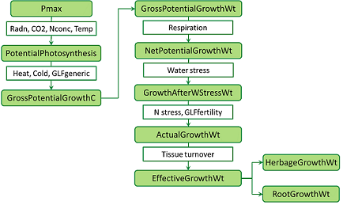

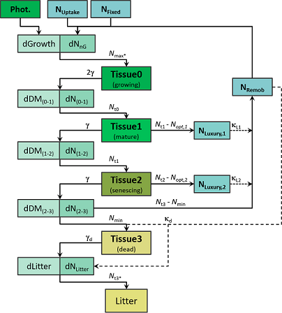

AgPasture does not account for phenological development, therefore it does not simulate reproductive growth and seed production. Instead, the model mimics changes in growth rate and dry matter allocation by using a simple function (based on latitude and some species specific parameters) that changes in the shoot:root ratio of plants during this "reproductive period". Another limitation of the model is the lack of carbon remobilisation, which makes it difficult to simulate the proper remobilisation of reserves in the plant. More details are given in the supplementary documentation for AgPasture. Biomass removal can be simulated by the Graze (Figure 5) and RemoveBiomass (Figure 6) methods. The Graze method is a simple way to present the amount of biomass to be removed. It uses a parameter 'Amount', which sets up the amount of dry matter to be removed, and a parameter 'Type', which defines how the value of 'Amount' is interpreted. 'Type' can be set as 'ResidueAmount', where the target amount of dry matter is a value for the residual amount of biomass that will be left after harvest, or it can be set as 'RemoveAMount', where the target amount of dry matter is the value to be removed by the harvest. Both methods are dependent on a minimum above ground green dry matter that is set as a default of 100 kg DM/ha and can never be removed. Then a function 'RemoveDM' is responsible for the dry matter removal and partitions the amount to be removed among organs and pools. This is dependent on default preference values, which are currently set as 1. A series of checks is done to guarantee that mass balance is not affected by the removal of dry matter. The 'RemoveBiomass' method is more elaborate and allows to control the amount of each organ and pool that will be removed. The fractions to be removed can be set through a 'RemovalType' or a 'RemovalData' parameter. The 'RemovalType' is based on default fractions for organs (leaves, stems and stolons) with fractions for live and dead pools of dry matter to be removed and residual dry matter. The 'RemovalData' is optional and allows the fractions to be removed to be set up by the user.

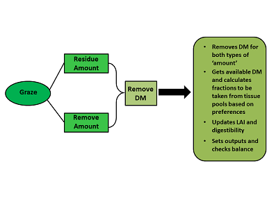

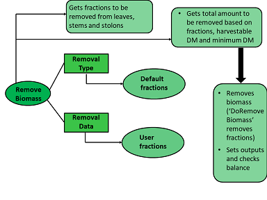

Figure 6. RemoveBiomass method of biomass removal in AgPasture.

Root distribution in AgPasture is give by a simple function, it follows an uniform distribution down to a certain depth, which can be set up by the user. From this depth on, the root system decreases following an exponential decline until no roots are present at the given maximum rooting depth (Figure 7).

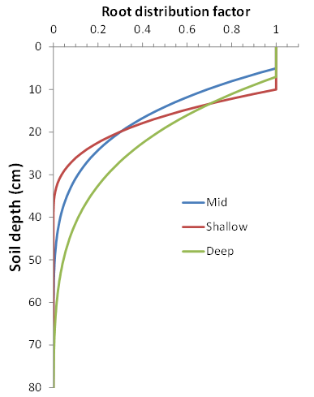

Describes a pasture species.

The model is constructed from the following list of software components. Details of the implementation and model parameterisation are provided in the following sections.

## 1.1 Plant Model Components

| Component Name | Component Type |
| --- | --- |
| Leaf | Models.AgPasture.PastureAboveGroundOrgan |
| Stem | Models.AgPasture.PastureAboveGroundOrgan |
| Stolon | Models.AgPasture.PastureAboveGroundOrgan |
| Root | Models.AgPasture.PastureBelowGroundOrgan |

## 1.2 Child Components

### 1.2.1 Leaf

Describes a generic above ground organ of a pasture species.

### 1.2.2 Stem

Describes a generic above ground organ of a pasture species.

### 1.2.3 Stolon

Describes a generic above ground organ of a pasture species.

### 1.2.4 Root

Describes a generic below ground organ of a pasture species.

Describes a pasture species.

The model is constructed from the following list of software components. Details of the implementation and model parameterisation are provided in the following sections.

## 1.3 Plant Model Components

| Component Name | Component Type |
| --- | --- |
| Leaf | Models.AgPasture.PastureAboveGroundOrgan |
| Stem | Models.AgPasture.PastureAboveGroundOrgan |
| Stolon | Models.AgPasture.PastureAboveGroundOrgan |
| Root | Models.AgPasture.PastureBelowGroundOrgan |

## 1.4 Child Components

### 1.4.1 Leaf

Describes a generic above ground organ of a pasture species.

### 1.4.2 Stem

Describes a generic above ground organ of a pasture species.

### 1.4.3 Stolon

Describes a generic above ground organ of a pasture species.

### 1.4.4 Root

Describes a generic below ground organ of a pasture species.

# 2 Validation

The validation of biomass production, N status, and relative species composition of AgPasture is done using a series of simulations based on a number of datasets. The base validation uses the 'Radcliffe trials', a series of dataset of yield measured in exclusion cages on grass-clover pastures across New Zealand. The second set comprises of two long term dataset that contain more detailed informatin on management and pasture yield for each harvest, these are a subset of the 'Winchmore' irrigation and fertility trials, with data from ryegrass-clover mixed pastures under rainfed and irrigated conditions, and another set based on production trials in 'Ruakura' McCall et al., 2003. The third set of simulations is based on a fertilisty trial conducted in 'Lincoln' and 'Ruakura' for the Forages for Reducing Nitorgen Leaching programme (FRNL); this encompases two years of biomass and N uptake measurements under six N fertilisation rates for monocultures of ryegrass and white clover, plus a mix of the two (only in Ruakura).

## 2.1 NewZealandLongTerm

| Experiment Name | Design (Number of Treatments) |
| --- | --- |
| Radcliffe | Location (33) |

The dataset used for this simulation is called the 'Radcliffe trials' because it was obtained from experiments done based on the methodology described by Radcliffe, 1974. This comprises a series of measurements on grass-clover pastures to evaluate pasture production across New Zealand. The data was obtained using exclusion cages set up in grazed pastures, with biomass harvested at variable intervals; in few locations plant composition was also determined. The data is presented summarised as the average annual production of dry matter per hectare. This validation set has experiments done in 33 locations, with some comprising two sets due to irrigation, lanscape factors, or different periods of observation. In total, there 37 sets are being used as a validation set for this simulation. Locations such as 'Arrowtown', 'Cromwell', 'PoolburnI', 'Awamoko', 'LowerWaitakiPlains', 'WinchmoreRedcliff' and 'WinchmoreIrrig' are irrigated trials, whereas the remaining locations are rainfed; in none of them N fertiliser was used. Note that in our simulations growth conditions that are not climate or nitrogen driven, are assumed to be non-limiting (i.e. soil fertility, pH, etc. are taken as near optimum and no pests or disease occured), this is a considerable leap of faith in some locations. Furthermore, the model is not considering variations in cultivars and the presence of weeds and other forages besides ryegrass and clover, plus pasplaum for the north-most locations (such variations in species composition are likely to have occured).

Two more data sets were added to the classic 'Radcliffe trials' with annual average production based on long term data of ryegrass-clover mixtured pasture production trials in 'Ruakura' and two areas in Winchmore ('WinchmoreDland', which is a dryland trial, and 'WinchmoreIrrig', which is an irrigated trial). More information about the 'Ruakura' data set can be found in McCall et al., 2003.

## 2.2 NewZealandDetailed

| Experiment Name | Design (Number of Treatments) |
| --- | --- |
| Winchmore | WaterMgmt (2) |
| RuakuraNo2 | WaterMgmt (1) |
| FRNLRuakuraMixedSward | NRate (6) |

### 2.2.1 FRNLWClover

| Experiment Name | Design (Number of Treatments) |
| --- | --- |
| FRNLLincolnWClover | NRate (6) |
| FRNLRuakuraWClover | NRate (6) |

### 2.2.2 FRNLRyegrass

| Experiment Name | Design (Number of Treatments) |
| --- | --- |
| FRNLLincolnRyegrass | NRate (6) |
| FRNLRuakuraRyegrass | NRate (6) |

# 3 Sensibility

| Experiment Name | Design (Number of Treatments) |
| --- | --- |
| Sensibility | Location x Nitrogen x Water (80) |

# 4 AGPRyegrass Interface

## 4.1 AGPRyegrass

**Parameters (Inputs)**

| Name | Description | Units | Type | Value |
| --- | --- | --- | --- | --- |
| PlantType | Flag indicating the type of plant (currently the name of the species)This used to be a marker for 'how leguminous' a plant was (in PMF and Stock).In AgPasture there is the parameter SpeciesFamily flag… |  | String | AGPRyegrass |
| Albedo | Canopy albedo, fraction of sun light reflected (0-1). | 0-1 | double | 0.26 |
| Gsmax | Maximum stomatal conductance (m/s). | m/s | double | 0.011 |
| R50 | Solar radiation at which stomatal conductance decreases to 50% (W/m^2). | W/m^2 | double | 200 |
| SpeciesFamily | Family type for this plant species (grass/legume/forb). | - | PlantFamilyType | Grass |
| PhotosyntheticPathway | Species metabolic pathway of C fixation during photosynthesis (C3/C4). |  | PhotosynthesisPathwayType | C3 |
| ReferencePhotosyntheticRate | Reference leaf CO2 assimilation rate for photosynthesis (mg CO2/m^2Leaf/s). | mg/m^2/s | double | 1 |
| LightExtinctionCoefficient | Light extinction coefficient (0-1). | 0-1 | double | 0.5 |
| GrowthTminimum | Minimum temperature for growth (oC). | oC | double | 2 |
| GrowthToptimum | Optimum temperature for growth (oC). | oC | double | 20 |
| GrowthTEffectExponent | Curve parameter for growth response to temperature (>0.0). | - | double | 1.6 |
| UseHeatStressFactor | Enable photosynthesis reduction due to heat damage (yes/no). | yes/no | YesNoAnswer | yes |
| HeatOnsetTemperature | Onset temperature for heat effects on photosynthesis (oC). | oC | double | 28 |
| HeatFullTemperature | Temperature for full heat effect on photosynthesis, growth stops (oC). | oC | double | 35 |
| HeatRecoverySumDD | Cumulative degrees-day for recovery from heat stress (oCd). | oCd | double | 30 |
| HeatRecoveryTReference | Reference temperature for recovery from heat stress (oC). | oC | double | 25 |
| UseColdStressFactor | Enable photosynthesis reduction due to cold damage is enabled (yes/no). | yes/no | YesNoAnswer | yes |
| ColdOnsetTemperature | Onset temperature for cold effects on photosynthesis (oC). | oC | double | 1 |
| ColdFullTemperature | Temperature for full cold effect on photosynthesis, growth stops (oC). | oC | double | -5 |
| ColdRecoverySumDD | Cumulative degrees for recovery from cold stress (oCd). | oCd | double | 25 |
| ColdRecoveryTReference | Reference temperature for recovery from cold stress (oC). | oC | double | 0 |
| MaintenanceRespirationCoefficient | Maintenance respiration coefficient (0-1). | 0-1 | double | 0.03 |
| GrowthRespirationCoefficient | Growth respiration coefficient (0-1). | 0-1 | double | 0.25 |
| RespirationTReference | Reference temperature for maintenance respiration (oC). | oC | double | 20 |
| RespirationExponent | Exponent controlling the effect of temperature on respiration (>1.0). | - | double | 1.5 |
| DegreesDayForGermination | Cumulative degrees-day needed for seed germination (oCd). | oCd | double | 125 |
| TargetShootRootRatio | Target, or ideal, shoot-root ratio (>0.0). | - | double | 3 |
| MaxRootAllocation | Maximum fraction of DM growth allocated to roots (0-1). | 0-1 | double | 0.325 |
| ShootRootGlfFactor | Maximum effect that soil GLFs have on Shoot-Root ratio (0-1). | 0-1 | double | 0.5 |
| UseReproSeasonFactor | Adjust Shoot:Root ratio to mimic DM allocation during reproductive season (perennial species)?. | yes/no | YesNoAnswer | yes |

[output cut: 93 more lines]

**Properties (Outputs)**

| Name | Description | Units | Type | Settable? |
| --- | --- | --- | --- | --- |
| CanopyType | Canopy type identifier. |  | String | True |
| LAI | Leaf Area Index of live tissues (m<sup>2/m</sup>2). | m<sup>2/m</sup>2 | double | True |
| LAITotal | Leaf Area Index of whole canopy, live + dead tissues (m<sup>2/m</sup>2). | m<sup>2/m</sup>2 | double | False |
| CoverGreen | Plant's green cover (0-1). | 0-1 | double | False |
| CoverTotal | Plant's total cover (0-1). | 0-1 | double | False |
| Height | Average canopy height (mm). | mm | double | False |
| Depth | Average canopy depth (mm). | mm | double | False |
| Width | Average canopy width (mm). | mm | double | False |
| FRGR | Plant growth limiting factor, supplied to MicroClimate for calculating potential transpiration. | 0-1 | double | False |
| PotentialEP | Potential evapotranspiration, as calculated by MicroClimate (mm). | mm | double | True |
| LightProfile | Light profile for this plant, interception calculated by MicroClimate (W/m^2).This contains the intercepted radiation for each layer of the canopy. |  | CanopyEnergyBalanceInterceptio... | True |
| IsC4 | Flag indicating whether the biomass is from a c4 plant or not |  | boolean | False |
| CultivarNames | List of cultivar names (not used by AgPasture). |  | String | False |
| IsReadyForHarvesting | Flag whether the crop is ready for harvesting. |  | boolean | False |
| InitialShootDM | Initial above ground DM weight (kgDM/ha). | kgDM/ha | double | True |
| InitialRootDM | Initial below ground DM weight (kgDM/ha). | kgDM/ha | double | True |
| InitialRootDepth | Initial rooting depth (mm). | mm | double | True |
| initialDMFractionsGrasses | Initial fractions of DM for each plant part in grasses (0-1). |  | double | True |
| initialDMFractionsLegumes | Initial fractions of DM for each plant part in legumes (0-1). |  | double | True |
| initialDMFractionsForbs | Initial fractions of DM for each plant part in forbs (0-1). |  | double | True |
| PhotosyntheticEfficiency | Leaf photosynthetic efficiency (mg CO2/J). | mg CO2/J | double | True |
| PhotosynthesisCurveFactor | Photosynthesis curvature parameter (J/kg/s). | J/kg/s | double | True |
| FractionPAR | Fraction of radiation that is photosynthetically active (0-1). | 0-1 | double | True |
| ReferenceCO2 | Reference CO2 concentration for photosynthesis (ppm). | ppm | double | True |
| CO2EffectScaleFactor | Scaling parameter for the CO2 effect on photosynthesis (ppm). | ppm | double | True |
| CO2EffectOffsetFactor | Scaling parameter for the CO2 effects on N requirements (ppm). | ppm | double | True |
| CO2EffectMinimum | Minimum value for the CO2 effect on N requirements (0-1). | 0-1 | double | True |
| CO2EffectExponent | Exponent controlling the CO2 effect on N requirements (>0.0). | - | double | True |
| ReproSeasonDurationCoeff | Coefficient controlling the duration of the reproductive season as function of latitude (-). | - | double | True |
| ReproSeasonShouldersLengthFactor | Ratio between the length of shoulders and the period with full reproductive growth effect (-). | - | double | True |

[output cut: 144 more lines]

**Links (Dependencies)**

| Name | Type | IsOptional? |
| --- | --- | --- |
| myClock | Clock | False |
| zone | Zone | False |
| myMetData | IWeather | False |
| mySummary | ISummary | False |
| soilPhysical | IPhysical | False |
| waterBalance | ISoilWater | False |
| microClimate | MicroClimate | False |
| roots | PastureBelowGroundOrgan | False |

**Events published**

| Name | Type |
| --- | --- |
| BiomassRemoved | Void BiomassRemoved (BiomassRemovedType Data) |

**Methods (callable from manager)**

| Name | Description |
| --- | --- |
| AddZone | void AddZone(String zoneName, double rootDepth, double rootDM)*Add a zone where roots are to grow.* |
| EvaluateLAI | void EvaluateLAI() |
| KillCrop | void KillCrop(double fractionToKill)*Kills a fraction of this plant.* |
| Reset | void Reset() |
| RemoveBiomass | Biomass RemoveBiomass(String type, double amount)*Removes plant material, from all organ, based on an amount given.Can be used to simulate a grazing event, with preferences for different organs.* |
| RemoveBiomass | Biomass RemoveBiomass(double amountToRemove, boolean doOutput)*Removes a given amount of biomass (DM and N) from the plant.* |
| EvaluateDigestibility | void EvaluateDigestibility() |
| ReduceCanopy | void ReduceCanopy(double deltaLAI)*Set the plant leaf area index.* |
| ReducePopulation | void ReducePopulation() |
| Sow | void Sow(String cultivar, double population, double depth, double rowSpacing, double maxCover, double budNumber, double rowConfig, double seeds, int32 tillering, double ftn)*Sows the plant.For AgPastu… |
| Harvest | void Harvest(boolean removeBiomassFromOrgans)*Harvests the crop.* |
| EndCrop | void EndCrop() |
| GetWaterUptakeEstimates | ZoneWaterAndN GetWaterUptakeEstimates(SoilState soilstate)*Gets the potential plant water uptake for each layer (mm).The model can only handle one root zone at present.* |
| GetNitrogenUptakeEstimates | ZoneWaterAndN GetNitrogenUptakeEstimates(SoilState soilstate)*Gets the potential plant N uptake for each layer (mm).The model can only handle one root zone at present.* |
| SetActualWaterUptake | void SetActualWaterUptake(ZoneWaterAndN zones) |
| SetActualNitrogenUptakes | void SetActualNitrogenUptakes(ZoneWaterAndN zones) |

## 4.2 PastureAboveGroundOrgan

Describes a generic above ground organ of a pasture species.

**Properties (Outputs)**

| Name | Description | Units | Type | Settable? |
| --- | --- | --- | --- | --- |
| EmergingTissue | Emerging aboveground organ tissue. |  | GenericTissue | True |
| DevelopingTissue | Developing aboveground organ tissue. |  | GenericTissue | True |
| MatureTissue | Mature aboveground organ tissue. |  | GenericTissue | True |
| DeadTissue | Dead aboveground organ tissue. |  | GenericTissue | True |
| LiveTissue | Collection of live aboveground organ tissues. |  | GenericTissue | True |
| NConcOptimum | N concentration for optimum growth (kg/kg). |  | double | True |
| NConcMinimum | Minimum N concentration, structural N (kg/kg). |  | double | True |
| NConcMaximum | Maximum N concentration, for luxury uptake (kg/kg). |  | double | True |
| FractionStanding | Proportion of organ DM that is standing, available to harvest (0-1). |  | double | True |
| MinimumLiveDM | Minimum DM amount of live tissues (kg/ha). |  | double | True |
| Material | A list of material (biomass) that can be damaged. |  | DamageableBiomass | False |
| IsAboveGround | Flag indicating whether the biomass is above ground or not. |  | boolean | False |
| Live | Return live biomass. Used by STOCK (g/m2). |  | Biomass | True |
| Dead | Dead biomass. Used by STOCK (g/m2). |  | Biomass | True |
| LiveDigestibility | Digestibility of live biomass. Used by STOCK (g/m2). |  | double | True |
| DeadDigestibility | Digestibility of dead biomass. Used by STOCK (g/m2). |  | double | True |
| DMTotal | Total dry matter in this organ (kg/ha). | kg/ha | double | False |
| DMLive | Dry matter in the live (green) tissues (kg/ha). | kg/ha | double | True |
| DMDead | Dry matter in the dead tissues (kg/ha). | kg/ha | double | False |
| StandingHerbageWt | Standing herbage weight (kg/ha). | kg/ha | double | False |
| StandingLiveHerbageWt | Standing live herbage weight (kg/ha). | kg/ha | double | False |
| StandingLiveDigestibility | Standing live digestibility (0-1). |  | double | False |
| StandingDeadDigestibility | Standing live digestibility (0-1). |  | double | False |
| StandingDeadHerbageWt | Standing dead herbage weight (kg/ha). | kg/ha | double | False |
| StandingLiveHerbageN | Standing live herbage weight (kg/ha). | kg/ha | double | False |
| StandingDeadHerbageN | Standing dead herbage weight (kg/ha). | kg/ha | double | False |
| StandingHerbageN | Standing herbage nitrogen (kg/ha). | kg/ha | double | False |
| DMTotalHarvestable | Total harvestable dry matter (kg/ha). | kg/ha | double | False |
| DMLiveHarvestable | Harvestable dry matter in the live (green) tissues (kg/ha). | kg/ha | double | False |
| DMDeadHarvestable | Dry matter in the dead tissues (kg/ha). | kg/ha | double | False |
| NTotalHarvestable | N in the total harvestable dry matter (kg/ha). | kg/ha | double | False |
| NLiveHarvestable | N in the harvestable dry matter in the live (green) tissues (kg/ha). | kg/ha | double | False |
| NDeadHarvestable | N in the harvestable dry matter in the dead tissues (kg/ha). | kg/ha | double | False |
| NTotal | Total N in this tissue (kg/ha). | kg/ha | double | False |
| NLive | N in the live (green) tissues (kg/ha). | kg/ha | double | True |
| NDead | N amount in the dead tissues (kg/ha). | kg/ha | double | False |
| NConcTotal | Average total N concentration. | kg/kg | double | False |
| NConcLive | Average N concentration in the live tissues (kg/kg). | kg/kg | double | False |
| NConcDead | Average N concentration in dead tissues (kg/kg). | kg/kg | double | False |
| NLuxuryRemobilisable | Luxury N available for remobilisation (kg/ha). |  | double | False |
| NLuxuryRemobilised | Luxury N remobilised into new growth (kg/ha). |  | double | False |
| NSenescedRemobilisable | Senesced N available for remobilisation (kg/ha). |  | double | False |
| NSenescedRemobilised | Senesced N remobilised into new growth (kg/ha). |  | double | False |
| DMSenesced | DM senescing from this organ (kg/ha). |  | double | False |
| NSenesced | N senescing from this organ (kg/ha). |  | double | False |
| DMDetached | DM detached from this organ (kg/ha). |  | double | False |
| NDetached | N detached from this organ (kg/ha). |  | double | False |
| DMRemoved | DM removed from this tissue (kg/ha). |  | double | False |
| NRemoved | N removed from this tissue (kg/ha). |  | double | False |
| FractionRemoved | Fraction of DM removed from organ. | kg/kg | double | False |
| DMGrowth | DM added to this organ via growth (kg/ha). |  | double | False |
| NGrowth | N added to this organ via growth (kg/ha). |  | double | False |
| DigestibilityTotal | Average digestibility of all biomass. | kg/kg | double | False |
| DigestibilityLive | Average digestibility of live biomass. | kg/kg | double | False |
| DigestibilityDead | Average digestibility of dead biomass. | kg/kg | double | False |
| StandingDigestibility | Digestibility of standing herbage. | kg/kg | double | False |

**Links (Dependencies)**

| Name | Type | IsOptional? |
| --- | --- | --- |
| species | PastureSpecies | False |
| Tissue | GenericTissue | False |

**Methods (callable from manager)**

| Name | Description |
| --- | --- |
| Initialise | void Initialise(double minimumLiveWt)*Initialise this organ instance (and tissues).* |
| SetBiomassState | void SetBiomassState(double emergingWt, double emergingN, double developingWt, double developingN, double matureWt, double matureN, double deadWt, double deadN)*Set this organ's biomass state.* |
| RemoveBiomass | double RemoveBiomass(double liveToRemove, double deadToRemove, double liveToResidue, double deadToResidue)*Remove biomass from organ.* |
| ClearDailyTransferredAmounts | void ClearDailyTransferredAmounts() |
| KillOrgan | void KillOrgan(double fractionToRemove)*Kills part of the organ (transfer DM and N to dead tissue).* |
| CalculateTissueTurnover | void CalculateTissueTurnover(double turnoverRate)*Computes the DM and N amounts turned over for all tissues.* |
| Update | boolean Update() |

## 4.3 AGPBiomass

AgPasture class for holding a biomass weight, N content and digestibility.

**Properties (Outputs)**

| Name | Description | Units | Type | Settable? |
| --- | --- | --- | --- | --- |
| Wt | Dry matter weight. | kg/ha | double | True |
| N | N content of biomass. | kg/ha | double | True |
| NConc | N concentration. | kg/ha | double | False |
| Digestibility | Digestibility of biomass. | kg/kg | double | True |
| ME | Average metabolisable energy concentration of standing herbage (MJ/kgDM). | MJ/kg | double | False |

## 4.4 TissuesHelper

Helper class for providing outputs from multiple tissues.

**Properties (Outputs)**

| Name | Description | Units | Type | Settable? |
| --- | --- | --- | --- | --- |
| Wt | Dry matter (kg/ha). | kg/ha | double | False |
| N | Nitrogen content (kg/ha). | kg/ha | double | False |

## 4.5 PastureBelowGroundOrgan

Describes a generic below ground organ of a pasture species.

**Properties (Outputs)**

| Name | Description | Units | Type | Settable? |
| --- | --- | --- | --- | --- |
| Live | Live root tissue. |  | RootTissue | True |
| Dead | Dead root tissue. |  | RootTissue | True |
| MinimumRootingDepth | Minimum rooting depth (mm). |  | double | True |
| MaximumPotentialRootingDepth | Maximum potential rooting depth (mm). |  | double | True |
| MaximumAllowedRootingDepth | Maximum rooting depth allowed by soil condition (mm). |  | double | True |
| ElongationRate | Daily root elongation rate at optimum temperature (mm/day). | mm/day | double | True |
| DepthDistributionParamTop | Factor for root distribution; depth from surface where root proportion starts to decrease (mm). | mm | double | True |
| DepthDistributionExponent | Exponent controlling the root distribution as function of depth (>0.0). | - | double | True |
| DepthDistributionParamBottom | Factor for root distribution; controls where the function is zero below maxRootDepth. |  | double | True |
| SpecificRootLength | Specific root length (m/gDM). |  | double | True |
| NConcOptimum | N concentration for optimum growth (kg/kg). |  | double | True |
| NConcMinimum | Minimum N concentration, structural N (kg/kg). |  | double | True |
| NConcMaximum | Maximum N concentration, for luxury uptake (kg/kg). |  | double | True |
| KNH4 | Ammonium uptake coefficient (/ppm). |  | double | True |
| KNO3 | Nitrate uptake coefficient (/ppm). |  | double | True |
| MaximumNUptake | Maximum daily amount of N that can be taken up by the plant (kg/ha). |  | double | True |
| MinimumLiveDM | Minimum DM amount of live tissues (kg/ha). |  | double | True |
| Depth | Rooting depth (mm). |  | double | True |
| DMSenesced | DM senescing from this organ (kg/ha). |  | double | False |
| NSenesced | N senescing from this organ (kg/ha). |  | double | False |
| DMDetached | DM detached from this organ (kg/ha). |  | double | False |
| NDetached | N detached from this organ (kg/ha). |  | double | False |
| DMRemoved | DM removed from this tissue (kg/ha). |  | double | False |
| NRemoved | N removed from this tissue (kg/ha). |  | double | False |
| DMGrowth | DM added to this organ via growth (kg/ha). |  | double | False |
| NGrowth | N added to this organ via growth (kg/ha). |  | double | False |
| LengthDensity | Root length density by volume (mm/mm^3). |  | double | False |

**Links (Dependencies)**

| Name | Type | IsOptional? |
| --- | --- | --- |
| species | PastureSpecies | False |
| Tissue | RootTissue | False |

**Methods (callable from manager)**

| Name | Description |
| --- | --- |
| DoRootGrowthAllocation | void DoRootGrowthAllocation(double rootDMToAdd, double rootNToAdd)*Computes the allocation of new growth to roots for each layer.The current target distribution for roots changes whenever the root dep… |
| EvaluateRootElongation | void EvaluateRootElongation(double dGrowthRootDM, double detachedRootDM, double temperatureLimitingFactor)*Computes the variations in root depth.Root depth will increase if it is smaller than maximumR… |
| PerformWaterUptake | void PerformWaterUptake(double amount)*Remove water from soil - uptake.* |
| PerformNutrientUptake | void PerformNutrientUptake(double no3Amount, double nh4Amount)*Remove nutrients from soil - uptake.* |
| IsInZone | boolean IsInZone(String zoneName)*Flag indicating whether roots are in the specified zone.* |
| Initialise | void Initialise(Zone zone, double minimumLiveWt)*Initialise this root instance (and tissues).* |
| SetBiomassState | void SetBiomassState(double rootWt, double rootN, double rootDepth)*Set this root organ's biomass state.* |
| RemoveBiomass | double RemoveBiomass(double liveToRemove, double deadToRemove, double liveToResidue, double deadToResidue)*Remove biomass from organ.* |
| RootDistributionTarget | double RootDistributionTarget() |
| CurrentRootDistributionTarget | double CurrentRootDistributionTarget() |

# 5 AGPWhiteClover Interface

## 5.1 AGPWhiteClover

**Parameters (Inputs)**

| Name | Description | Units | Type | Value |
| --- | --- | --- | --- | --- |
| PlantType | Flag indicating the type of plant (currently the name of the species)This used to be a marker for 'how leguminous' a plant was (in PMF and Stock).In AgPasture there is the parameter SpeciesFamily flag… |  | String | AGPWhiteClover |
| Albedo | Canopy albedo, fraction of sun light reflected (0-1). | 0-1 | double | 0.26 |
| Gsmax | Maximum stomatal conductance (m/s). | m/s | double | 0.011 |
| R50 | Solar radiation at which stomatal conductance decreases to 50% (W/m^2). | W/m^2 | double | 200 |
| SpeciesFamily | Family type for this plant species (grass/legume/forb). | - | PlantFamilyType | Legume |
| PhotosyntheticPathway | Species metabolic pathway of C fixation during photosynthesis (C3/C4). |  | PhotosynthesisPathwayType | C3 |
| ReferencePhotosyntheticRate | Reference leaf CO2 assimilation rate for photosynthesis (mg CO2/m^2Leaf/s). | mg/m^2/s | double | 1 |
| LightExtinctionCoefficient | Light extinction coefficient (0-1). | 0-1 | double | 0.8 |
| GrowthTminimum | Minimum temperature for growth (oC). | oC | double | 4 |
| GrowthToptimum | Optimum temperature for growth (oC). | oC | double | 22.5 |
| GrowthTEffectExponent | Curve parameter for growth response to temperature (>0.0). | - | double | 1.6 |
| UseHeatStressFactor | Enable photosynthesis reduction due to heat damage (yes/no). | yes/no | YesNoAnswer | yes |
| HeatOnsetTemperature | Onset temperature for heat effects on photosynthesis (oC). | oC | double | 30 |
| HeatFullTemperature | Temperature for full heat effect on photosynthesis, growth stops (oC). | oC | double | 36 |
| HeatRecoverySumDD | Cumulative degrees-day for recovery from heat stress (oCd). | oCd | double | 20 |
| HeatRecoveryTReference | Reference temperature for recovery from heat stress (oC). | oC | double | 25 |
| UseColdStressFactor | Enable photosynthesis reduction due to cold damage is enabled (yes/no). | yes/no | YesNoAnswer | yes |
| ColdOnsetTemperature | Onset temperature for cold effects on photosynthesis (oC). | oC | double | 3 |
| ColdFullTemperature | Temperature for full cold effect on photosynthesis, growth stops (oC). | oC | double | -3 |
| ColdRecoverySumDD | Cumulative degrees for recovery from cold stress (oCd). | oCd | double | 35 |
| ColdRecoveryTReference | Reference temperature for recovery from cold stress (oC). | oC | double | 2 |
| MaintenanceRespirationCoefficient | Maintenance respiration coefficient (0-1). | 0-1 | double | 0.04 |
| GrowthRespirationCoefficient | Growth respiration coefficient (0-1). | 0-1 | double | 0.275 |
| RespirationTReference | Reference temperature for maintenance respiration (oC). | oC | double | 20 |
| RespirationExponent | Exponent controlling the effect of temperature on respiration (>1.0). | - | double | 1.55 |
| DegreesDayForGermination | Cumulative degrees-day needed for seed germination (oCd). | oCd | double | 125 |
| TargetShootRootRatio | Target, or ideal, shoot-root ratio (>0.0). | - | double | 3.5 |
| MaxRootAllocation | Maximum fraction of DM growth allocated to roots (0-1). | 0-1 | double | 0.3 |
| ShootRootGlfFactor | Maximum effect that soil GLFs have on Shoot-Root ratio (0-1). | 0-1 | double | 0.5 |
| UseReproSeasonFactor | Adjust Shoot:Root ratio to mimic DM allocation during reproductive season (perennial species)?. | yes/no | YesNoAnswer | yes |

[output cut: 93 more lines]

**Properties (Outputs)**

| Name | Description | Units | Type | Settable? |
| --- | --- | --- | --- | --- |
| CanopyType | Canopy type identifier. |  | String | True |
| LAI | Leaf Area Index of live tissues (m<sup>2/m</sup>2). | m<sup>2/m</sup>2 | double | True |
| LAITotal | Leaf Area Index of whole canopy, live + dead tissues (m<sup>2/m</sup>2). | m<sup>2/m</sup>2 | double | False |
| CoverGreen | Plant's green cover (0-1). | 0-1 | double | False |
| CoverTotal | Plant's total cover (0-1). | 0-1 | double | False |
| Height | Average canopy height (mm). | mm | double | False |
| Depth | Average canopy depth (mm). | mm | double | False |
| Width | Average canopy width (mm). | mm | double | False |
| FRGR | Plant growth limiting factor, supplied to MicroClimate for calculating potential transpiration. | 0-1 | double | False |
| PotentialEP | Potential evapotranspiration, as calculated by MicroClimate (mm). | mm | double | True |
| LightProfile | Light profile for this plant, interception calculated by MicroClimate (W/m^2).This contains the intercepted radiation for each layer of the canopy. |  | CanopyEnergyBalanceInterceptio... | True |
| IsC4 | Flag indicating whether the biomass is from a c4 plant or not |  | boolean | False |
| CultivarNames | List of cultivar names (not used by AgPasture). |  | String | False |
| IsReadyForHarvesting | Flag whether the crop is ready for harvesting. |  | boolean | False |
| InitialShootDM | Initial above ground DM weight (kgDM/ha). | kgDM/ha | double | True |
| InitialRootDM | Initial below ground DM weight (kgDM/ha). | kgDM/ha | double | True |
| InitialRootDepth | Initial rooting depth (mm). | mm | double | True |
| initialDMFractionsGrasses | Initial fractions of DM for each plant part in grasses (0-1). |  | double | True |
| initialDMFractionsLegumes | Initial fractions of DM for each plant part in legumes (0-1). |  | double | True |
| initialDMFractionsForbs | Initial fractions of DM for each plant part in forbs (0-1). |  | double | True |
| PhotosyntheticEfficiency | Leaf photosynthetic efficiency (mg CO2/J). | mg CO2/J | double | True |
| PhotosynthesisCurveFactor | Photosynthesis curvature parameter (J/kg/s). | J/kg/s | double | True |
| FractionPAR | Fraction of radiation that is photosynthetically active (0-1). | 0-1 | double | True |
| ReferenceCO2 | Reference CO2 concentration for photosynthesis (ppm). | ppm | double | True |
| CO2EffectScaleFactor | Scaling parameter for the CO2 effect on photosynthesis (ppm). | ppm | double | True |
| CO2EffectOffsetFactor | Scaling parameter for the CO2 effects on N requirements (ppm). | ppm | double | True |
| CO2EffectMinimum | Minimum value for the CO2 effect on N requirements (0-1). | 0-1 | double | True |
| CO2EffectExponent | Exponent controlling the CO2 effect on N requirements (>0.0). | - | double | True |
| ReproSeasonDurationCoeff | Coefficient controlling the duration of the reproductive season as function of latitude (-). | - | double | True |
| ReproSeasonShouldersLengthFactor | Ratio between the length of shoulders and the period with full reproductive growth effect (-). | - | double | True |

[output cut: 144 more lines]

**Links (Dependencies)**

| Name | Type | IsOptional? |
| --- | --- | --- |
| myClock | Clock | False |
| zone | Zone | False |
| myMetData | IWeather | False |
| mySummary | ISummary | False |
| soilPhysical | IPhysical | False |
| waterBalance | ISoilWater | False |
| microClimate | MicroClimate | False |
| roots | PastureBelowGroundOrgan | False |

**Events published**

| Name | Type |
| --- | --- |
| BiomassRemoved | Void BiomassRemoved (BiomassRemovedType Data) |

**Methods (callable from manager)**

| Name | Description |
| --- | --- |
| AddZone | void AddZone(String zoneName, double rootDepth, double rootDM)*Add a zone where roots are to grow.* |
| EvaluateLAI | void EvaluateLAI() |
| KillCrop | void KillCrop(double fractionToKill)*Kills a fraction of this plant.* |
| Reset | void Reset() |
| RemoveBiomass | Biomass RemoveBiomass(String type, double amount)*Removes plant material, from all organ, based on an amount given.Can be used to simulate a grazing event, with preferences for different organs.* |
| RemoveBiomass | Biomass RemoveBiomass(double amountToRemove, boolean doOutput)*Removes a given amount of biomass (DM and N) from the plant.* |
| EvaluateDigestibility | void EvaluateDigestibility() |
| ReduceCanopy | void ReduceCanopy(double deltaLAI)*Set the plant leaf area index.* |
| ReducePopulation | void ReducePopulation() |
| Sow | void Sow(String cultivar, double population, double depth, double rowSpacing, double maxCover, double budNumber, double rowConfig, double seeds, int32 tillering, double ftn)*Sows the plant.For AgPastu… |
| Harvest | void Harvest(boolean removeBiomassFromOrgans)*Harvests the crop.* |
| EndCrop | void EndCrop() |
| GetWaterUptakeEstimates | ZoneWaterAndN GetWaterUptakeEstimates(SoilState soilstate)*Gets the potential plant water uptake for each layer (mm).The model can only handle one root zone at present.* |
| GetNitrogenUptakeEstimates | ZoneWaterAndN GetNitrogenUptakeEstimates(SoilState soilstate)*Gets the potential plant N uptake for each layer (mm).The model can only handle one root zone at present.* |
| SetActualWaterUptake | void SetActualWaterUptake(ZoneWaterAndN zones) |
| SetActualNitrogenUptakes | void SetActualNitrogenUptakes(ZoneWaterAndN zones) |

## 5.2 PastureAboveGroundOrgan

Describes a generic above ground organ of a pasture species.

**Properties (Outputs)**

| Name | Description | Units | Type | Settable? |
| --- | --- | --- | --- | --- |
| EmergingTissue | Emerging aboveground organ tissue. |  | GenericTissue | True |
| DevelopingTissue | Developing aboveground organ tissue. |  | GenericTissue | True |
| MatureTissue | Mature aboveground organ tissue. |  | GenericTissue | True |
| DeadTissue | Dead aboveground organ tissue. |  | GenericTissue | True |
| LiveTissue | Collection of live aboveground organ tissues. |  | GenericTissue | True |
| NConcOptimum | N concentration for optimum growth (kg/kg). |  | double | True |
| NConcMinimum | Minimum N concentration, structural N (kg/kg). |  | double | True |
| NConcMaximum | Maximum N concentration, for luxury uptake (kg/kg). |  | double | True |
| FractionStanding | Proportion of organ DM that is standing, available to harvest (0-1). |  | double | True |
| MinimumLiveDM | Minimum DM amount of live tissues (kg/ha). |  | double | True |
| Material | A list of material (biomass) that can be damaged. |  | DamageableBiomass | False |
| IsAboveGround | Flag indicating whether the biomass is above ground or not. |  | boolean | False |
| Live | Return live biomass. Used by STOCK (g/m2). |  | Biomass | True |
| Dead | Dead biomass. Used by STOCK (g/m2). |  | Biomass | True |
| LiveDigestibility | Digestibility of live biomass. Used by STOCK (g/m2). |  | double | True |
| DeadDigestibility | Digestibility of dead biomass. Used by STOCK (g/m2). |  | double | True |
| DMTotal | Total dry matter in this organ (kg/ha). | kg/ha | double | False |
| DMLive | Dry matter in the live (green) tissues (kg/ha). | kg/ha | double | True |
| DMDead | Dry matter in the dead tissues (kg/ha). | kg/ha | double | False |
| StandingHerbageWt | Standing herbage weight (kg/ha). | kg/ha | double | False |
| StandingLiveHerbageWt | Standing live herbage weight (kg/ha). | kg/ha | double | False |
| StandingLiveDigestibility | Standing live digestibility (0-1). |  | double | False |
| StandingDeadDigestibility | Standing live digestibility (0-1). |  | double | False |
| StandingDeadHerbageWt | Standing dead herbage weight (kg/ha). | kg/ha | double | False |
| StandingLiveHerbageN | Standing live herbage weight (kg/ha). | kg/ha | double | False |
| StandingDeadHerbageN | Standing dead herbage weight (kg/ha). | kg/ha | double | False |
| StandingHerbageN | Standing herbage nitrogen (kg/ha). | kg/ha | double | False |
| DMTotalHarvestable | Total harvestable dry matter (kg/ha). | kg/ha | double | False |
| DMLiveHarvestable | Harvestable dry matter in the live (green) tissues (kg/ha). | kg/ha | double | False |
| DMDeadHarvestable | Dry matter in the dead tissues (kg/ha). | kg/ha | double | False |
| NTotalHarvestable | N in the total harvestable dry matter (kg/ha). | kg/ha | double | False |
| NLiveHarvestable | N in the harvestable dry matter in the live (green) tissues (kg/ha). | kg/ha | double | False |
| NDeadHarvestable | N in the harvestable dry matter in the dead tissues (kg/ha). | kg/ha | double | False |
| NTotal | Total N in this tissue (kg/ha). | kg/ha | double | False |
| NLive | N in the live (green) tissues (kg/ha). | kg/ha | double | True |
| NDead | N amount in the dead tissues (kg/ha). | kg/ha | double | False |
| NConcTotal | Average total N concentration. | kg/kg | double | False |
| NConcLive | Average N concentration in the live tissues (kg/kg). | kg/kg | double | False |
| NConcDead | Average N concentration in dead tissues (kg/kg). | kg/kg | double | False |
| NLuxuryRemobilisable | Luxury N available for remobilisation (kg/ha). |  | double | False |
| NLuxuryRemobilised | Luxury N remobilised into new growth (kg/ha). |  | double | False |
| NSenescedRemobilisable | Senesced N available for remobilisation (kg/ha). |  | double | False |
| NSenescedRemobilised | Senesced N remobilised into new growth (kg/ha). |  | double | False |
| DMSenesced | DM senescing from this organ (kg/ha). |  | double | False |
| NSenesced | N senescing from this organ (kg/ha). |  | double | False |
| DMDetached | DM detached from this organ (kg/ha). |  | double | False |
| NDetached | N detached from this organ (kg/ha). |  | double | False |
| DMRemoved | DM removed from this tissue (kg/ha). |  | double | False |
| NRemoved | N removed from this tissue (kg/ha). |  | double | False |
| FractionRemoved | Fraction of DM removed from organ. | kg/kg | double | False |
| DMGrowth | DM added to this organ via growth (kg/ha). |  | double | False |
| NGrowth | N added to this organ via growth (kg/ha). |  | double | False |
| DigestibilityTotal | Average digestibility of all biomass. | kg/kg | double | False |
| DigestibilityLive | Average digestibility of live biomass. | kg/kg | double | False |
| DigestibilityDead | Average digestibility of dead biomass. | kg/kg | double | False |
| StandingDigestibility | Digestibility of standing herbage. | kg/kg | double | False |

**Links (Dependencies)**

| Name | Type | IsOptional? |
| --- | --- | --- |
| species | PastureSpecies | False |
| Tissue | GenericTissue | False |

**Methods (callable from manager)**

| Name | Description |
| --- | --- |
| Initialise | void Initialise(double minimumLiveWt)*Initialise this organ instance (and tissues).* |
| SetBiomassState | void SetBiomassState(double emergingWt, double emergingN, double developingWt, double developingN, double matureWt, double matureN, double deadWt, double deadN)*Set this organ's biomass state.* |
| RemoveBiomass | double RemoveBiomass(double liveToRemove, double deadToRemove, double liveToResidue, double deadToResidue)*Remove biomass from organ.* |
| ClearDailyTransferredAmounts | void ClearDailyTransferredAmounts() |
| KillOrgan | void KillOrgan(double fractionToRemove)*Kills part of the organ (transfer DM and N to dead tissue).* |
| CalculateTissueTurnover | void CalculateTissueTurnover(double turnoverRate)*Computes the DM and N amounts turned over for all tissues.* |
| Update | boolean Update() |

## 5.3 AGPBiomass

AgPasture class for holding a biomass weight, N content and digestibility.

**Properties (Outputs)**

| Name | Description | Units | Type | Settable? |
| --- | --- | --- | --- | --- |
| Wt | Dry matter weight. | kg/ha | double | True |
| N | N content of biomass. | kg/ha | double | True |
| NConc | N concentration. | kg/ha | double | False |
| Digestibility | Digestibility of biomass. | kg/kg | double | True |
| ME | Average metabolisable energy concentration of standing herbage (MJ/kgDM). | MJ/kg | double | False |

## 5.4 TissuesHelper

Helper class for providing outputs from multiple tissues.

**Properties (Outputs)**

| Name | Description | Units | Type | Settable? |
| --- | --- | --- | --- | --- |
| Wt | Dry matter (kg/ha). | kg/ha | double | False |
| N | Nitrogen content (kg/ha). | kg/ha | double | False |

## 5.5 PastureBelowGroundOrgan

Describes a generic below ground organ of a pasture species.

**Properties (Outputs)**

| Name | Description | Units | Type | Settable? |
| --- | --- | --- | --- | --- |
| Live | Live root tissue. |  | RootTissue | True |
| Dead | Dead root tissue. |  | RootTissue | True |
| MinimumRootingDepth | Minimum rooting depth (mm). |  | double | True |
| MaximumPotentialRootingDepth | Maximum potential rooting depth (mm). |  | double | True |
| MaximumAllowedRootingDepth | Maximum rooting depth allowed by soil condition (mm). |  | double | True |
| ElongationRate | Daily root elongation rate at optimum temperature (mm/day). | mm/day | double | True |
| DepthDistributionParamTop | Factor for root distribution; depth from surface where root proportion starts to decrease (mm). | mm | double | True |
| DepthDistributionExponent | Exponent controlling the root distribution as function of depth (>0.0). | - | double | True |
| DepthDistributionParamBottom | Factor for root distribution; controls where the function is zero below maxRootDepth. |  | double | True |
| SpecificRootLength | Specific root length (m/gDM). |  | double | True |
| NConcOptimum | N concentration for optimum growth (kg/kg). |  | double | True |
| NConcMinimum | Minimum N concentration, structural N (kg/kg). |  | double | True |
| NConcMaximum | Maximum N concentration, for luxury uptake (kg/kg). |  | double | True |
| KNH4 | Ammonium uptake coefficient (/ppm). |  | double | True |
| KNO3 | Nitrate uptake coefficient (/ppm). |  | double | True |
| MaximumNUptake | Maximum daily amount of N that can be taken up by the plant (kg/ha). |  | double | True |
| MinimumLiveDM | Minimum DM amount of live tissues (kg/ha). |  | double | True |
| Depth | Rooting depth (mm). |  | double | True |
| DMSenesced | DM senescing from this organ (kg/ha). |  | double | False |
| NSenesced | N senescing from this organ (kg/ha). |  | double | False |
| DMDetached | DM detached from this organ (kg/ha). |  | double | False |
| NDetached | N detached from this organ (kg/ha). |  | double | False |
| DMRemoved | DM removed from this tissue (kg/ha). |  | double | False |
| NRemoved | N removed from this tissue (kg/ha). |  | double | False |
| DMGrowth | DM added to this organ via growth (kg/ha). |  | double | False |
| NGrowth | N added to this organ via growth (kg/ha). |  | double | False |
| LengthDensity | Root length density by volume (mm/mm^3). |  | double | False |

**Links (Dependencies)**

| Name | Type | IsOptional? |
| --- | --- | --- |
| species | PastureSpecies | False |
| Tissue | RootTissue | False |

**Methods (callable from manager)**

| Name | Description |
| --- | --- |
| DoRootGrowthAllocation | void DoRootGrowthAllocation(double rootDMToAdd, double rootNToAdd)*Computes the allocation of new growth to roots for each layer.The current target distribution for roots changes whenever the root dep… |
| EvaluateRootElongation | void EvaluateRootElongation(double dGrowthRootDM, double detachedRootDM, double temperatureLimitingFactor)*Computes the variations in root depth.Root depth will increase if it is smaller than maximumR… |
| PerformWaterUptake | void PerformWaterUptake(double amount)*Remove water from soil - uptake.* |
| PerformNutrientUptake | void PerformNutrientUptake(double no3Amount, double nh4Amount)*Remove nutrients from soil - uptake.* |
| IsInZone | boolean IsInZone(String zoneName)*Flag indicating whether roots are in the specified zone.* |
| Initialise | void Initialise(Zone zone, double minimumLiveWt)*Initialise this root instance (and tissues).* |
| SetBiomassState | void SetBiomassState(double rootWt, double rootN, double rootDepth)*Set this root organ's biomass state.* |
| RemoveBiomass | double RemoveBiomass(double liveToRemove, double deadToRemove, double liveToResidue, double deadToResidue)*Remove biomass from organ.* |
| RootDistributionTarget | double RootDistributionTarget() |
| CurrentRootDistributionTarget | double CurrentRootDistributionTarget() |

# 6 Science Documentation

[View science documentation here](https://apsimdev.apsim.info/ApsimX/Documents/AgPastureScience.pdf)

# 7 Species Table

## 7.1 SpeciesTable

Listed in the table below are the default values for all parameters for all AgPasture species

| Parameter name | Ryegrass | WhiteClover | Browntop | Cocksfoot | Kikuyu | Lucerne | Paspalum | Phalaris | RedClover | Rhodes | TallFescue |
| --- | --- | --- | --- | --- | --- | --- | --- | --- | --- | --- | --- |
| PlantType | AGPRyegrass | AGPWhiteClover | AGPBrownTop | AGPCocksfoot | AGPKikuyu | AGPLucerne | AGPPaspalum | AGPPhalaris | AGPRedClover | AGPRhodes | AGPTallFescue |
| Albedo | 0.26 | 0.26 | 0.26 | 0.26 | 0.26 | 0.26 | 0.26 | 0.26 | 0.26 | 0.26 | 0.26 |
| Gsmax | 0.011 | 0.011 | 0.011 | 0.011 | 0.011 | 0.011 | 0.011 | 0.011 | 0.011 | 0.011 | 0.011 |
| R50 | 200 | 200 | 200 | 200 | 200 | 200 | 200 | 200 | 200 | 200 | 200 |
| SpeciesFamily | Grass | Legume | Grass | Grass | Grass | Legume | Grass | Grass | Legume | Grass | Grass |
| PhotosyntheticPathway | C3 | C3 | C3 | C3 | C4 | C3 | C4 | C3 | C3 | C4 | C3 |
| ReferencePhotosyntheticRate | 1 | 1 | 1 | 1 | 1.2 | 1 | 1.2 | 1 | 1 | 1.2 | 1 |
| LightExtinctionCoefficient | 0.5 | 0.8 | 0.5 | 0.5 | 0.5 | 0.65 | 0.5 | 0.5 | 0.7 | 0.5 | 0.5 |
| GrowthTminimum | 2 | 4 | 2 | 2 | 10 | 5 | 10 | 2 | 4 | 10 | 2 |
| GrowthToptimum | 20 | 22.5 | 20 | 20 | 22 | 25 | 33 | 20 | 23 | 35 | 20 |
| GrowthTEffectExponent | 1.6 | 1.6 | 1.7 | 1.7 | 1.2 | 1.7 | 1.25 | 1.7 | 1.7 | 1.25 | 1.7 |
| UseHeatStressFactor | yes | yes | yes | yes | yes | yes | yes | yes | yes | yes | yes |
| HeatOnsetTemperature | 28 | 30 | 26 | 26 | 38 | 28 | 35 | 28 | 30 | 35 | 28 |
| HeatFullTemperature | 35 | 36 | 35 | 35 | 48 | 35 | 40 | 35 | 37 | 42 | 35 |
| HeatRecoverySumDD | 30 | 20 | 20 | 20 | 30 | 25 | 20 | 30 | 20 | 30 | 20 |
| HeatRecoveryTReference | 25 | 25 | 25 | 25 | 38 | 27 | 30 | 30 | 30 | 35 | 28 |
| UseColdStressFactor | yes | yes | yes | yes | yes | yes | yes | yes | yes | yes | yes |
| ColdOnsetTemperature | 1 | 3 | 1 | 1 | 6 | 3 | 8 | 2 | 3 | 8 | 2 |
| ColdFullTemperature | -5 | -3 | -3 | -3 | 1 | -2 | 2 | -2 | -3 | 3 | -3 |
| ColdRecoverySumDD | 25 | 35 | 20 | 20 | 50 | 30 | 50 | 25 | 35 | 50 | 30 |
| ColdRecoveryTReference | 0 | 2 | 0 | 0 | 4 | 0 | 6 | 1.5 | 0 | 5 | 0 |
| MaintenanceRespirationCoefficient | 0.03 | 0.04 | 0.03 | 0.03 | 0.03 | 0.04 | 0.03 | 0.03 | 0.04 | 0.03 | 0.03 |
| GrowthRespirationCoefficient | 0.25 | 0.275 | 0.25 | 0.25 | 0.25 | 0.275 | 0.25 | 0.25 | 0.275 | 0.25 | 0.25 |
| RespirationTReference | 20 | 20 | 20 | 20 | 20 | 20 | 20 | 20 | 20 | 20 | 20 |
| RespirationExponent | 1.5 | 1.55 | 1.5 | 1.5 | 1.4 | 1.5 | 1.4 | 1.5 | 1.55 | 1.5 | 1.45 |
| DegreesDayForGermination | 125 | 125 | 125 | 125 | 150 | 125 | 150 | 125 | 110 | 150 | 125 |
| TargetShootRootRatio | 3 | 3.5 | 2 | 3 | 1.5 | 3.5 | 2.5 | 3 | 3.75 | 2 | 3 |
| MaxRootAllocation | 0.325 | 0.3 | 0.45 | 0.325 | 0.5 | 0.312 | 0.4 | 0.325 | 0.3 | 0.45 | 0.325 |
| ShootRootGlfFactor | 0.5 | 0.5 | 0.6 | 0.5 | 0.6 | 0.5 | 0.6 | 0.5 | 0.5 | 0.6 | 0.5 |
| UseReproSeasonFactor | yes | yes | yes | yes | yes | yes | yes | yes | yes | yes | yes |

[output cut: 94 more lines]

# 8 References

Johnson, I. R., Chapman, D. F., Snow, V. O., Eckard, R. J., Parsons, A. J., Lambert, M. G., Cullen, B. R., 2008. DairyMod and EcoMod: biophysical pasture-simulation models for Australia and new Zealand. Australian Journal of Experimental Agriculture 48 (5), 621-631.

Li, F. Y., Snow, V. O., Holzworth, D. P., 2011. Modelling the seasonal and geographical pattern of pasture production in New Zealand. New Zealand Journal of Agricultural Research 54 (4), 331-352.

McCall, DG, Bishop-Hurley, GJ, 2003. A pasture growth model for use in a whole-farm dairy production model. Agricultural Systems 76 (3), 1183-1205.

Radcliffe, JE, 1974. Seasonal distribution of pasture production in New Zealand: I. Methods of measurement. New Zealand journal of experimental agriculture 2 (4), 337-340.

Snow, V. O., Huth, N. I., 2004. The APSIM–MICROMET module.. HortResearch Internal Report No. 2004/12848. Auckland, HortResearch..

Thornley, John HM, Johnson, Ian R, 1990. Plant and crop modelling..

Vogeler, I, Cichota, R, 2016. Deriving seasonally optimal nitrogen fertilization rates for a ryegrass pasture based on agricultural production systems simulator modelling with a refined AgPasture model. Grass and Forage Science 71 (3), 353-365.